# Encuesta Percepciones sobre Democracia y Tecnología en Argentina

Fernanda López Franz

2023-08-04

## Introducción

Entre febrero y marzo del año 2023, se realizó la **Encuesta Percepciones sobre Democracia y Tecnología en Argentina**. El objetivo consistió en conocer las percepciones sobre la democracia y las tecnologías de la información y la comunicación de los y las argentinas que acceden a la red de puntos digitales del Programa Punto Digital.Se realizaron encuestas a todos los Puntos Digitales de todas las provincas argentinas y el número de respuestas varía de acuerdo al número de Puntos Digitales instalados en cada jurisdicción.Se obtuvieron respuestas en 270 Puntos Digitales.

Los **Puntos Digitales** son dispositivos de inclusión digital libres y gratuitos instalados en todas las provincias argentinas y dependientes de la Secretaría de Innovación Pública perteneciente a la Jefatura de Gabinete de Ministros.

Este trabajo es una primera aproximación a la lectura de los datos relevados por la Encuesta, y que esperamos puedan seguir analizándose en el marco del trabajo en el Programa Punto Digital. Los mayores avances que pudimos realizar, se refieren a la presentación de los datos recabados, y algunos cruces entre variables.

**Presentación de los datos**

Sobre el lugar de residencia de las personas que contestaron la encuesta, podemos decir que alrededor del 25% de las personas encuestadas participa de los Puntos Digitales instalados en la provincia de Buenos Aires, seguidos por las provincias de Córdoba y Entre Ríos. La variación en la cantidad de las respuestas se debe a varios factores. En primer lugar, al número de Puntos Digitales instalados en cada jurisdicción.En segundo término, al nivel de respuesta que los Equipos Locales de trabajo tienen con el Equipo Nacional al momento de cumplir con los requerimientos del Programa (en este caso, llevar adelante la encuesta).

**Cantidad de respuestas por provincia**

| Provincia | Total | Porcentaje |
| --- | --- | --- |
| Buenos Aires | 573 | 26.06 |
| Córdoba | 256 | 11.64 |
| Entre Ríos | 241 | 10.96 |
| Tucumán | 146 | 6.64 |
| Misiones | 137 | 6.23 |
| Santa Fe | 128 | 5.82 |
| Jujuy | 79 | 3.59 |
| Corrientes | 64 | 2.91 |
| San Juan | 62 | 2.82 |
| Salta | 61 | 2.77 |
| Chubut | 57 | 2.59 |
| Río Negro | 55 | 2.50 |
| Chaco | 48 | 2.18 |
| Mendoza | 43 | 1.96 |
| Santiago del Estero | 42 | 1.91 |
| Catamarca | 41 | 1.86 |
| San Luis | 37 | 1.68 |
| Neuquén | 29 | 1.32 |
| Santa Cruz | 23 | 1.05 |
| La Rioja | 20 | 0.91 |
| Formosa | 18 | 0.82 |
| Ciudad Autónoma de Buenos Aires | 17 | 0.77 |
| La Pampa | 14 | 0.64 |
| Tierra del Fuego, Antártida e Islas del Atlántico Sur | 8 | 0.36 |

Fuente: Encuesta sobre percepciones sobre la Democracia y Tecnologías (2023)

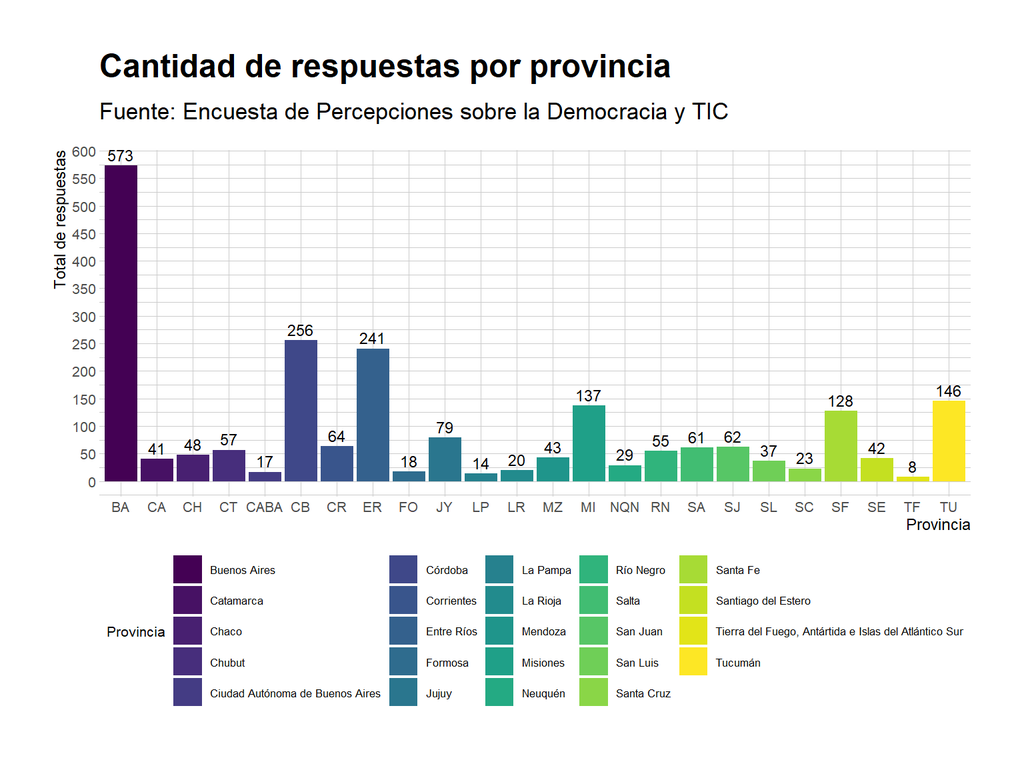

EDAD DE LAS PERSONAS ENCUESTADAS

| Máximo Edad |
| --- |
| 84 |

| Mínimo Edad |
| --- |
| 16 |

| Media Edad |
| --- |
| 35.85812 |

GÉNERO

**Distribución de respuestas por género**

| Género | Total | Porcentaje |
| --- | --- | --- |
| Mujer | 1338 | 60.85 |
| Varón | 816 | 37.11 |
| Prefiero no especificarlo | 21 | 0.95 |
| No binario | 12 | 0.55 |
| Mujer trans | 8 | 0.36 |
| Travesti | 3 | 0.14 |
| Varón trans | 1 | 0.05 |

Fuente: Encuesta sobre percepciones sobre la Democracia y Tecnologías (2023)

RANGO ETARIO

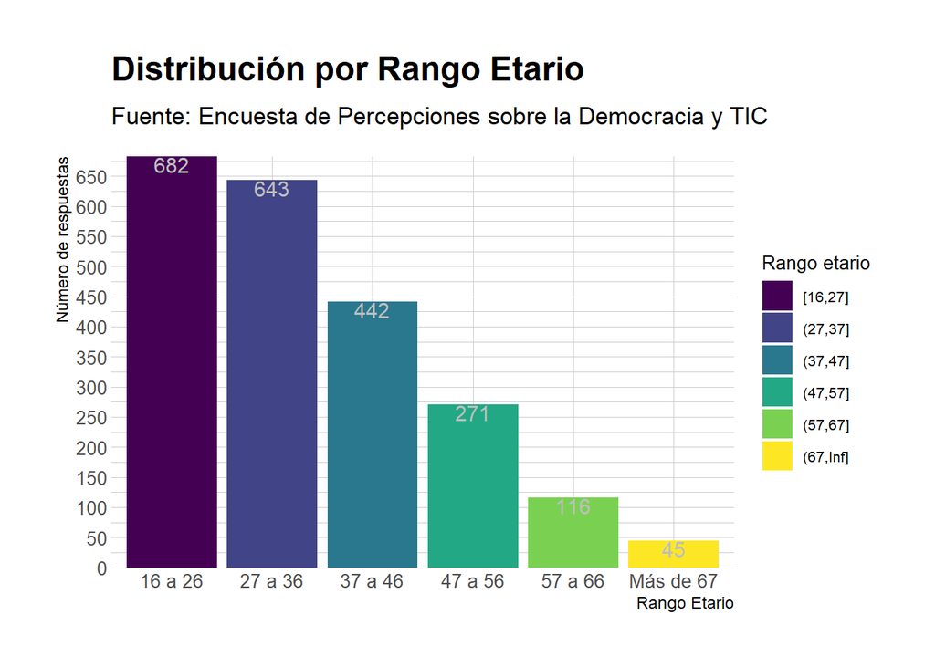

NIVEL EDUCATIVO

**Respuestas por nivel educativo**

| Nivel Educativo | Frecuencia | Porcentaje |
| --- | --- | --- |
| Secundaria completa | 641 | 29.15 |
| Terciario completo | 381 | 17.33 |
| Secundaria incompleta | 293 | 13.32 |
| Terciario incompleto | 250 | 11.37 |
| Universitario incompleto | 250 | 11.37 |
| Universitario completo | 206 | 9.37 |
| Primaria completa | 97 | 4.41 |
| Primaria incompleta | 42 | 1.91 |
| Post universitario completo | 36 | 1.64 |
| Sin estudios | 2 | 0.09 |
| Ns/Nc | 1 | 0.05 |

Fuente: Encuesta sobre percepciones sobre la Democracia y Tecnologías (2023)

TRABAJO

Casi el 80 % de la población encuestada trabaja.

```
## # A tibble: 2 × 2
##   Trabajo Total
##   <chr>   <int>
## 1 No        469
## 2 Sí       1730
```

PRIMERAS RELACIONES

Casi la totalidad de las personas considera que la democracia es preferible a cualquier otra forma de gobierno.

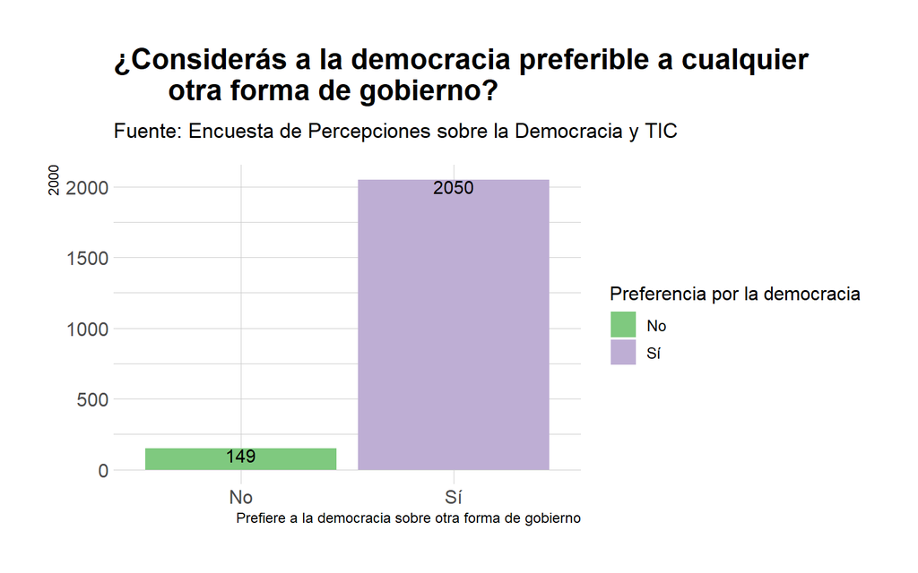

Si analizamos la relación entre el rango etario y la respuesta a la pregunta ¿considerás a la democracia preferible a cualquier otra forma de gobierno? **no observamos variaciones significativas entre los diferentes rangos etarios**.

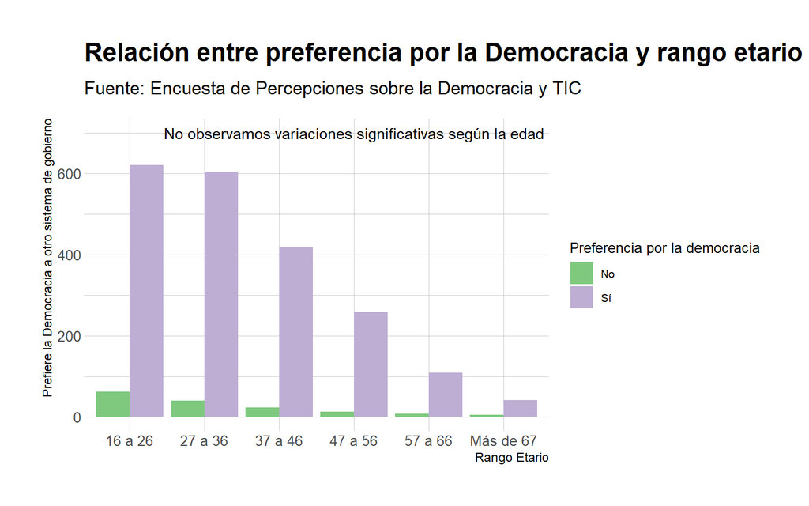

Encontramos diferencias en la preferencia a la democracia sobre otro sistema de gobierno, entre las personas que trabajan y las personas que no trabajan.

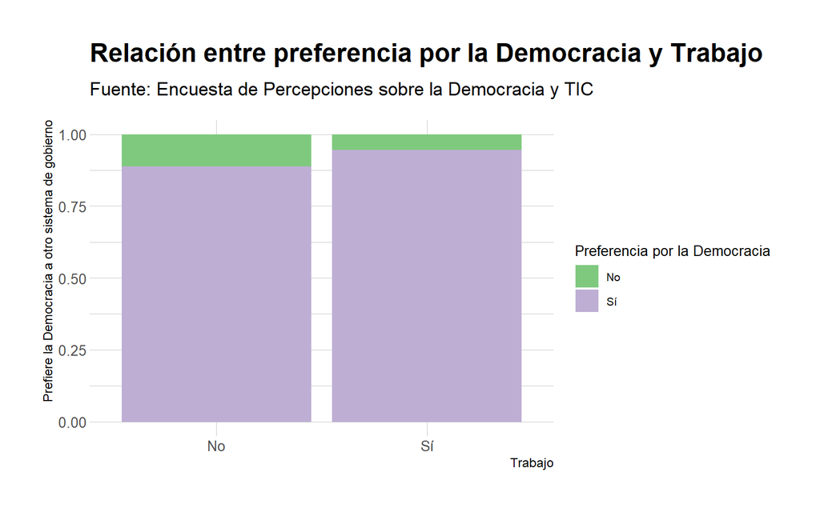

**Grado de satisfacción con la democracia**

| Grado de Satisfacción con la democracia | Total | Porcentaje |
| --- | --- | --- |
| Satisfecho | 888 | 40.38 |
| Poco satisfecho | 733 | 33.33 |
| Muy satisfecho | 223 | 10.14 |
| Insatisfecho | 209 | 9.50 |
| Muy insatisfecho | 146 | 6.64 |

Fuente: Encuesta sobre percepciones sobre la Democracia y Tecnologías (2023)

RELACIÓN ENTRE GRADO DE SATISFACCIÓN CON LA DEMOCRACIA Y EDAD